# Unit 2 : Data Visualizations and R Basics

# 1 Introduction

Welcome back to POLI LIT! By now, you’ve had a chance to explore what data is and how it can help us understand the world. In **Unit 2**, we’re going to shift gears and focus on something just as important: **how to show data clearly and effectively**.

This unit covers two main areas:

1. **Understanding good data visualization**  
   What makes a chart or graph *actually helpful*? We’ll go over types of visualizations (like bar charts, scatterplots, and more), and learn how visual design can either *reveal* or *confuse* information.
2. **Learning how to create visualizations in R using `ggplot2`**  
   You’ll get hands-on with R and Posit Cloud (a free, browser-based platform), and learn how to build and customize plots. No downloads or complicated installs needed!

By the end of this unit, you should feel confident in your ability to use R to create clear and compelling data visualizations. That doesn’t mean flashy colors or 3D charts — it means charts that clearly communicate important information and help others focus on what matters.

**What to Submit for Full Credit**

To receive full credit for Unit 2, make sure you submit the following:

- *Final Practice (Plot + Description)*
- *Unit 2 Feedback Form*

Optional plot activity is available in the unit — this is **not required**, but completing the task will really help reinforce your learning.

> 💡 *We strongly encourage you to follow each step in the unit carefully. Practicing along with the examples will make it much easier to complete the final tasks.*

## 1.1 Getting Started: Can You Read These Plots?

Before we dive deeper, here are **two types of plots** you should already be somewhat familiar with:

- A line plot (often used to show change over time)
- A bar plot (used to compare categories)

Take a look at the code below for each plot. Don’t worry if it looks a little confusing — just do your best to follow along and think about what each part is doing.

> 🔍 Can you guess what each line of code is doing? Try to connect the code to the visual output.

### 1.1.1 Line plot

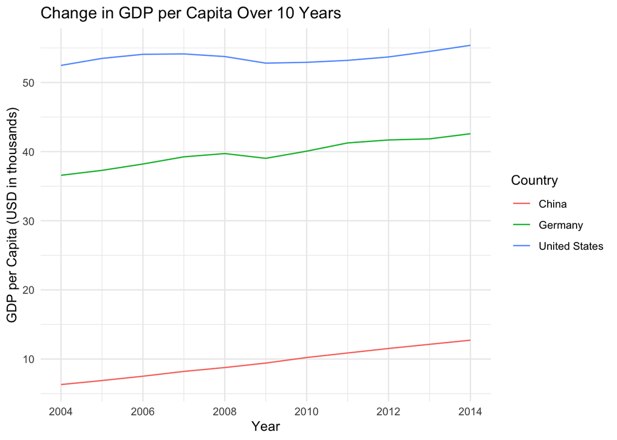

```r
p1 <- POLI_LIT %>%
  filter(year >= 2004) %>%
  filter(country_name %in% c("United States", "China", "Germany"))

ggplot(p1, aes(x = year, y = e_gdppc, colour = country_name)) +
  geom_line() +
  labs(
    x = "Year",
    y = "GDP per Capita (USD in thousands)",
    title = "Change in GDP per Capita Over 10 Years",
    colour = "Country"
  ) +
  theme_minimal()
```

**How to read this plot**:

- The x-axis shows time in years.
- The y-axis shows each country’s GDP per person (a common measure of national income).
- Each colored line represents one country.

This kind of line plot helps us track economic changes over time and compare how different countries grow or slow down.

### 1.1.2 Bar plot

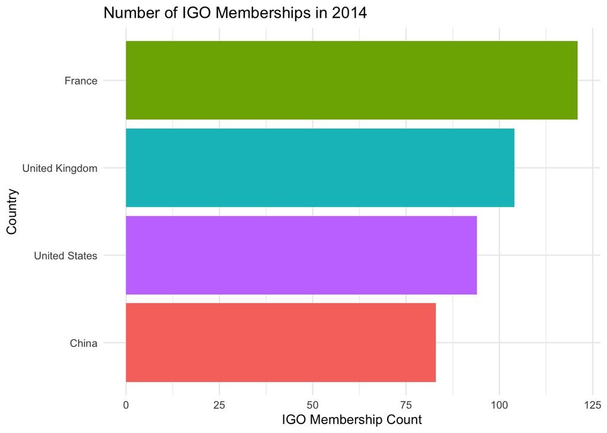

```r
p2 <- POLI_LIT %>%
  filter(year == 2014) %>%
  filter(country_name %in% c("United States", "China", "France","United Kingdom"))

ggplot(p2, aes(x = reorder(country_name, IGO_count), y = IGO_count, fill = country_name)) +
  geom_col(show.legend = FALSE) +
  coord_flip() +
  labs(
    title = "Number of IGO Memberships in 2014",
    x = "Country",
    y = "IGO Membership Count"
  ) +
    theme_minimal()
```

**How to read this plot**:

- Each bar represents one country.
- The height of the bar shows how many international organizations (IGOs) that country belonged to in 2014.
- Countries like the United States, France, and the United Kingdom usually appear near the top because they join many IGOs, reflecting their strong global involvement.

Even a simple bar plot like this invites us to think about how countries engage with the world—highlighting important themes like global participation and cooperation through IGOs.

## 1.2 What is R and RStudio?

Now that you’ve seen some example plots, take a closer look at the **code** that created them.  
Notice how each part of the code tells R exactly **what we want to do**:

- `filter()` helps us *select* specific years or countries from a dataset
- `labs()` is used to *customize labels* like the plot title or axis names
- `geom_col()` or `geom_line()` decides *what kind of plot* to draw

Each function serves a purpose — just like giving precise instructions to a robot.

If this is your first time writing code, don’t stress. Just follow the steps one by one — we’ll guide you the whole way.Our main goal for R coding in this unit is for you to:

- Set up your R environment using Posit Cloud (a browser-based tool — no installation needed)
- Learn the basic structure of R code
- Make your first visualization using R and the `ggplot2` package

> 💡Coding in R is not like talking to an AI chatbot. R follows your instructions **exactly as written** — so things like spelling, punctuation, and parentheses really matter. A small typo can cause your code not to run!

### 1.2.1 What is R

**R** is a computer language made for **data analysis and visualization**.  
Scientists, journalists, and governments use it every day to understand information and share results clearly.

You can think of R as a **toolbox** filled with functions for:

- Reading and organizing data
- Doing calculations and statistics
- Making graphs and maps

R is also **open-source**, which means it’s free and anyone can improve it.  
Because of that, thousands of researchers around the world—especially in *political science* —build and share new tools for others to use.

Learn more about other trending languages here - [“Top 12 Programming Languages for Data Science Languages in 2025.”](https://www.datacamp.com/blog/top-programming-languages-for-data-scientists-in-2022).

### 1.2.2 What is RStudio / Posit Cloud?

When you use R by itself, you are typing commands into a plain window—just a blinking cursor waiting for instructions. That works fine for experts, but it can feel uncomfortable if you are new to coding.

That is why we use **RStudio**. RStudio is a program that makes R much easier to use. It gives you a clear, organized workspace so you can see your code, data, and results all in one place (You might see people call RStudio an *IDE*, which stands for *Integrated Development Environment*).

Don’t worry if that sounds technical. It just means that RStudio brings everything you need together in one space:

- You can **write** code.
- You can **run** code and see what happens.
- You can **look at** your data and graphs.
- You can **get help** when something does not work.

In short, an IDE is a workspace that combines all your tools in one window. Instead of installing RStudio on your own computer, we will use **Posit Cloud**, which is the online platform to run RStudio.It works right in your web browser—just like Google Docs—so you do not need to install anything.

[figure not shown]

> **A way to think about this dynamic:**  
> - *R* is the *engine* that makes the car move.  
> - *RStudio* (or Posit Cloud) is the *dashboard* that helps you drive the car safely and easily. The dashboard shows your speed, directions, and fuel level—so you can focus on where you are going, not how the engine works.

## 1.3 Using Posit Cloud

### 1.3.1 How to Create and Open a Project on Posit Cloud

To start working with R and coding, we will use **Posit Cloud**, a platform/website that lets you use RStudio in your web browser.

If you already have *R* and *RStudio* installed on your computer, you can follow along with this unit using your desktop version. But for this module, we recommend **Posit Cloud** for everyone who are trying R the first time. You don’t have to install anything— everything runs online and is saved automatically.

- **Step 1: Register for a Free Account**

  Visit https://posit.cloud and click **Sign Up** to create a free account.You can sign in using Google or GitHub if you prefer.

  Once you’ve registered, Posit Cloud will open your personal workspace—just like logging into Google Drive for the first time.
- **Step 2: Create or Open a Project**

  A *project* is like a folder that keeps everything you do in one place: your code, datasets, and any graphs or reports you make. You can think of a project as your personal research folder inside RStudio. Keeping your work in projects helps you stay organized and avoid mixing files from different assignments.

  **Follow the steps in this webpage** to create your first project (read up to the *“Start Shiny App Steps”* section.):  
  [How to get started with Posit Cloud (Posit Docs)](https://docs.posit.co/cloud/get_started/)

### 1.3.2 Understanding the Interface

When your project opens, you’ll see the **RStudio / Posit Cloud workspace**.  
It looks like this:

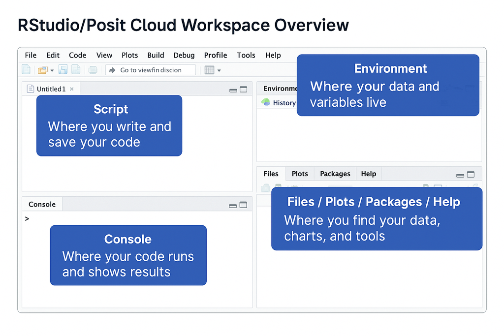

When you open **RStudio** the first time, you should notice the screen is divided into **four main panels**. Each one plays a different role — and together, they make writing and running R code much easier.

- **Script Editor** (Top-Left)  
  This is your *notebook*.  
  Write your code here and save it for later.  
  You can run a line (or section) by clicking the *Run* button or pressing `Cmd + Enter` (Mac) / `Ctrl + Enter` (Windows).
- **Console** (Bottom-Left)  
  This is R’s *work area*.  
  When you run code, the Console shows what’s happening — results, errors, or messages.  
  Think of it as R’s “chat box”: it shows replies to your commands.
- **Environment & History** (Top-Right)  
  – *Environment:* Keeps track of what you’ve created — datasets, variables, etc.  
  – *History:* A record of every command you’ve run.
- **Files / Plots / Packages / Help** (Bottom-Right)  
  – *Files:* Shows what’s saved in your R project folder.  
  – *Plots:* Displays the graphs you create.  
  – *Packages:* Lists extra tools you’ve installed.  
  – *Help:* Use this when you forget how a function works!

> 🔍 As you work through this unit, don’t be afraid to click around each panel in RStudio to see what it does. You don’t need to memorize everything — just knowing where things are will help a lot. Also, if you close your browser, Posit Cloud automatically saves your work.

### 1.3.3 Setting the Working Directory

Before we start analyzing data, you need to tell R where your files live. This location is called your **working directory** — it’s the folder R looks in when you open or save things.

You should already have your **Posit Cloud account** set up now. For this step, please download the **POLI_LIT dataset** and the **codebook PDF** from Blackboard Unit 2 folder.

Save both files on your computer:

- `POLI_LIT_v1.csv`
- `POLI_LIT_v1_codebook.pdf`

> 💡On Posit Cloud, you can upload files directly to your project. If you’re using RStudio on your computer instead, make sure your data file and your `.Rmd` file are saved in the **same folder** so R can find them.

#### 1.3.3.1 Why the Working Directory Matters

Think of your working directory as R’s *home base or inventory.* If R doesn’t know where to look, it can’t find your data or save your charts.

- When you read a file (data), R looks in your working directory and load it into R Studio.
- When you save a graph, R also saves it there by default.

You can **check** or **set** your working directory using these commands:

```r
getwd()   # shows your current working directory
setwd("/cloud/project")  # sets it to your Posit Cloud project folder
```

> **On Posit Cloud:** Your project folder is automatically your working directory (`/cloud/project`).  
> **On RStudio Desktop:** You need to set your working directory manually through `setwd("your folder path")` code.  
> In `.rmd` and `.qmd` file, using r code need code chunk, check this link for more: [here](https://rmarkdown.rstudio.com/lesson-3.html)

### 1.3.4 Uploading Datasets

Now that R knows where to look, let’s bring your dataset into R!

Follow these steps carefully:

1. In Posit Cloud, go to the **Files** tab (bottom-right panel).
2. Click the **Upload** button.
3. Select your dataset file — `POLI_LIT_v1.csv`.
4. Once it uploads, you should see it appear in the Files panel.

Now, we’ll read it into R using this code:

```r
POLI_LIT <- read.csv("POLI_LIT_v1.csv")
head(POLI_LIT)
```

This code tells R to:

- **Read** the CSV file named `POLI_LIT_v1.csv`, and
- **Show** the first six rows of data using the `head()` function.

If it worked, you’ll see a small preview of your dataset that looks like this:

[figure not shown]

> 💡 If R says *“cannot open file”* or *“no such file”*, check that your file name matches exactly (including capital letters) and that it’s saved in your working directory.  
> [Official guide of input data into posit cloud](https://docs.posit.co/cloud/guide/data/)  
> [Video to input data and export result file](https://youtu.be/FSiDrlOAjgo?si=4LGmjU2apnAcfesZ)  
> If you are using *RStudio installed on device*, you can follow this official guide:  
> [Importing data into RStudio (Posit Support)](https://docs.posit.co/ide/user/ide/guide/data/data-local.html)

Next, you can click on the “POLI_LIT” in your environment panel to open the viewing window for data like this:

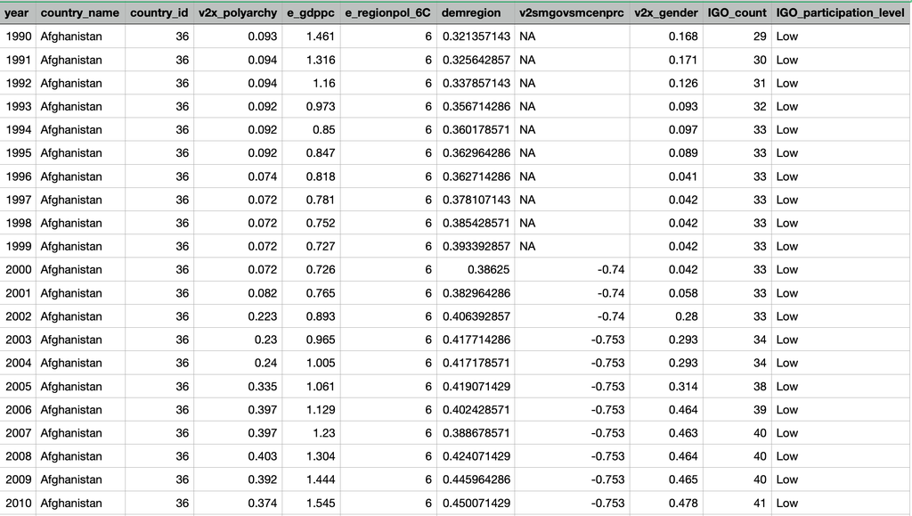

Coming up next, we’ll make our **first simple plot** using the POLI_LIT dataset.  
You’ll see how just a few lines of code can turn raw data into a clear and meaningful visualization!

## 1.4 Knowledge check

### 1.4.1 Check List

Before continue to the next section, make sure you:

1. Register Posit Cloud account and open your first project.
2. Run `getwd()` to check your working directory.
3. Upload `POLI_LIT_v1.csv` and read it with `read.csv()`.
4. Type `head(POLI_LIT)` to view the first few rows.

### 1.4.2 Practice Quiz

**1. Which part of the RStudio interface shows your R commands and error messages?**

a) Environment

b) Files pane

c) Console

**2. The Script Editor (top-left panel) is used for:**

a) Writing and saving code you want to reuse

b) Showing images only

c) Installing packages only

**3. What does the command `getwd()` do?**

a) Uploads your dataset

b) Shows your current working directory

c) Runs a plot

**4. R and RStudio are the same thing.**

a) True

b) False

**5. A small typing error (like a missing parenthesis) can prevent R code from running.**

a) True

b) False

# 2 Exploring R: Basic

In this section, we will explore what R can *do* and *learn the basic logic* behind how it works.  
You have already seen R Studio’s workspace and learned how to create a project. R might look complicated at first, but at its core, it is simply a tool that:

- reads and stores data
- performs calculations
- helps us analyze and visualize data

Think of R as a **powerful calculator** that can also work with entire datasets.

We’ll start with small steps so you can get comfortable running code and understanding what R is doing.

## 2.1 Writing R Code

Besides working with existing datasets, R can also do many other tasks—like solving math problems or making quick calculations. This is a good way to practice how R ‘thinks’ and ‘operate.’

You can write and run code in two places:

- **Console:** for quick, one-time commands.
- **Script Editor:** for code you want to save and reuse later.

If you’re not sure where these are, go back to the previous section *“Using Posit Cloud”* and look at the workspace diagram.

> 💡 R reads and runs commands **line by line**.  
> You can run a line of code by selecting the line(s) and pressing **Run** (the green button at the top of your Script pane) or using **Ctrl + Enter** (Windows) / **Cmd + Enter** (Mac).

### 2.1.1 Try It Yourself: Basic Math in R

R can do simple math just like a calculator. Copy and paste the code below into your Posit Cloud project. You’ll see results in the **Console**, right below your commands.

```r
# --- 1. Basic Math Operations ---
# R can perform mathematical calculations directly.
# Try Copy Paste these and run in your project!

5 + 3   # Addition
10 - 4  # Subtraction
6 * 7   # Multiplication
20 / 5  # Division
2^3     # Exponentiation
sqrt(25) # Square root

# Other useful functions:
log(10)  # Natural logarithm
exp(2)   # Exponential function
round(3.14159, 2)  # Rounds to 2 decimal places
```

### 2.1.2 What You’ll See

When you run these commands, R prints each answer immediately in the Console.

It looks like this:

```r
6 * 7    # Multiplication
```

```
## [1] 42
```

```r
sqrt(25) # Square root
```

```
## [1] 5
```

```r
log(10)  # Natural logarithm
```

```
## [1] 2.302585
```

```r
exp(2)   # Exponential function
```

```
## [1] 7.389056
```

> 💡 **Important:**  
> Text that starts with the `#` symbol is a **comment**. Use comments to make notes for yourself—what the code does, or why you wrote it.  
> For example: `5 + 3 # Adds 5 and 3 together`. R ignores anything that comes after `#` on a line. So it will print ‘8’ as result and ignore ‘Adds 5 and 3 together.’

## 2.2 What is a Variable or Object?

Now that you can run simple commands, the next step is to learn how R stores information using **objects** (also called **variables**).

You can think of an object as a labeled box where R keeps something you want to use later-

A *number*, *text*, a *list of values*, or even a whole *dataset*.

### 2.2.1 Creating a Variable (or Object)

R stores information in objects that you can name yourself. You create an object using the **assignment arrow** `<-`, which means: take the value on the right and store it in the name on the left.

```r
# Example: create an object
x <- 5  #store the value 5 in the object call 'x'
y <- 10 #store the value 10 in 'y'

# Use objects in calculations
x + y # add them
```

Here, `x` and `y` store numeric values (5 and 10), and R keeps track of them until you remove them or end your session.

> 💡 You’ll see all your objects appear in the **Environment** pane (top-right).

### 2.2.2 What Can R Store in Objects?

R objects can contain many kinds of information, including a single number, a text string (e.g., “India”), a **vector** (a list of values), or a **data frame** (a full dataset with rows and columns).

When you load a dataset using `read.csv` function like this:

```r
data <- read.csv("POLI_LIT_v1.csv")
```

The `<-` assigns the dataset to the object named `data`.

You can name it to anything you like, such as `poli_lit`, `df`, or `mydata`. Like this:

```r
POLI_LIT <- read.csv("POLI_LIT_v1.csv")
```

Now the entire dataset (POLI_LIT_v1.csv) is stored in an object named `POLI_LIT`.

### 2.2.3 What About the `$` Symbol?

When you import a dataset, it becomes a **data frame**, which works like a table. Each column has a name, and the `$` operator lets you access one column at a time.

Example:

```r
data$year
# This means - take the column named 'year' from the dataset (object) called 'data'

poli_data$v2x_polyarchy
# Take the column named 'v2x_polyarchy' from the dataset (object) called 'poli_data'
```

You can use `$` to look at values, calculate statistics, use the variable in a plot, or filter/subset your data. You will use $ frequently when summarizing variables or making plots!

Example:

```r
mean(data$v2x_polyarchy)
# Caculate the mean of variable (column) 'v2x_polyarchy' from the dataframe (object) called 'data'
```

## 2.3 Understanding Data Types and Exploring Data

Now that we’ve learned about the basic, we will explore the practice dataset you loaded earlier (`POLI_LIT_v1.csv`). This dataset is stored in an object (dataframe) called `POLI_LIT`.

Each column (or *variable*) in this dataset can have a different **data type** — some are numbers, others are text, and some may be logical (TRUE/FALSE). Knowing these types helps you decide which functions or visualizations to use.

### 2.3.1 Uploading and Loading the Dataset

These commands help R locate your files and load your dataset:

```r
getwd()   # shows your current working directory
setwd("/cloud/project")  # sets it to your Posit Cloud project folder

POLI_LIT <- road.csv("POLI_LIT_v1.csv") #load the csv file and name it 'POLI_LIT '
```

> 💡 If the file name is not typed exactly the same, R will not find it (e,g. the use of capital letters, `-` and `_`!).

Start by looking at what the dataset contains: `head()`command shows the first six rows your dataframe.

This gives you a quick preview of how the data is structured, like this:

```r
head(POLI_LIT) # load 6 rows of your loaded dataset
```

```
##   year country_name country_id v2x_polyarchy e_gdppc e_regionpol_6C demregion
## 1 1990       Mexico          3         0.396  11.389              2   0.55928
## 2 1991       Mexico          3         0.418  11.635              2   0.57996
## 3 1992       Mexico          3         0.441  11.883              2   0.58480
## 4 1993       Mexico          3         0.451  11.983              2   0.59928
## 5 1994       Mexico          3         0.472  12.043              2   0.60964
## 6 1995       Mexico          3         0.489  11.742              2   0.61876
##   v2smgovsmcenprc v2x_gender IGO_count IGO_participation_level
## 1              NA      0.534        74                    High
## 2              NA      0.505        73                    High
## 3              NA      0.505        72                    High
## 4              NA      0.516        74                    High
## 5              NA      0.631        82                    High
## 6              NA      0.636        83                    High
```

### 2.3.2 Check the Structure and Data Types

We can also check what kind of data each column holds using `str()`.

```r
str(POLI_LIT) # Shows the structure of the dataset
```

```
## 'data.frame':    3314 obs. of  11 variables:
##  $ year                   : int  1990 1991 1992 1993 1994 1995 1996 1997 1998 1999 ...
##  $ country_name           : chr  "Mexico" "Mexico" "Mexico" "Mexico" ...
##  $ country_id             : int  3 3 3 3 3 3 3 3 3 3 ...
##  $ v2x_polyarchy          : num  0.396 0.418 0.441 0.451 0.472 0.489 0.511 0.56 0.599 0.605 ...
##  $ e_gdppc                : num  11.4 11.6 11.9 12 12 ...
##  $ e_regionpol_6C         : int  2 2 2 2 2 2 2 2 2 2 ...
##  $ demregion              : num  0.559 0.58 0.585 0.599 0.61 ...
##  $ v2smgovsmcenprc        : num  NA NA NA NA NA NA NA NA NA NA ...
##  $ v2x_gender             : num  0.534 0.505 0.505 0.516 0.631 0.636 0.636 0.636 0.636 0.636 ...
##  $ IGO_count              : int  74 73 72 74 82 83 83 83 84 86 ...
##  $ IGO_participation_level: chr  "High" "High" "High" "High" ...
```

The `str()` function will tell you:

- Rows and columns count
- A preview of the data
- The **data type** of each column, such as:
  - *numeric*: numbers (e.g., GDP per capita)
  - *character*: text (e.g., country names)
  - *integer*: whole numbers (e.g., year)

### 2.3.3 Try Built-In Summary Functions

R provides lots of built-in functions that help us quickly understand a dataset:

```r
summary(POLI_LIT)         # Summarizes all variables in the dataset
nrow(POLI_LIT)            # Number of rows (observations)
ncol(POLI_LIT)            # Number of columns (variables)
colnames(POLI_LIT)        # Lists all column names
```

> 💡 These are essential tools for exploring unfamiliar data.Try running them one by one and see what they return!

### 2.3.4 Analyze a Single Variable

```r
mean(POLI_LIT$demregion, na.rm = TRUE)
```

You can also get a quick overview of a specific column:

```r
summary(POLI_LIT$demregion)
```

```
##    Min. 1st Qu.  Median    Mean 3rd Qu.    Max.
##  0.1827  0.3724  0.4501  0.5168  0.6482  0.8844
```

> 🔍 Replace `demregion` with other column(variable) name, such as `year`, `country_name` or `IGO_count.` What information does it provide?

## 2.4 Practice (Optional)

1. Create and print an object: For example, run `x <- 5` and then type x to display its value.
2. Load the dataset and view basic summaries: Use `summary(POLI_LIT)` to see an overview of all variables.
3. Explore the structure of the dataset: Run the following and write a short comment on what each one shows:
   - `head(POLI_LIT)`
   - `str(POLI_LIT)`
   - `nrow(POLI_LIT)`
   - `ncol(POLI_LIT)`
4. Analyze a single variable: `mean(POLI_LIT$e_gdppc, na.rm = TRUE)` Explain what this number represents in the context of your dataset.

After completing these steps, try write few sentences describing:

- what type of dataset you are working with, and
- what that variable measures and the descriptive statistics (mean, max/min value etc).

## 2.5 Knowledge check

### 2.5.1 Check List

Before continuing to the next section, make sure you can:

1. Run basic R commands in the Console and Script Editor.
2. Create objects using `<-` and understand how R stores them.
3. Load the dataset using `read.csv()` and see it in your Environment.
4. Use the `$` operator to access a single variable.
5. Run basic data exploration functions:
   - `head()`
   - `str()`
   - `summary()`
   - `nrow() and ncol()`
6. Explain (in simple words) what a data frame is and what a variable is.

### 2.5.2 Pratice Quiz

**1. What does `na.rm = TRUE` do in a function like `mean()`?**

a) Ignores missing values

b) Converts all values to NA

c) Rounds values

**2. Which function shows the first few rows of a dataset?**

a) summary()

b) head()

c) names()

**3. What does this code do? `x <- 10`**

a) Prints the number 10

b) Creates an object named x that stores the value 10

c) Multiplies x by 10

**4. R ignores any text after a `#` symbol on a line.**

a) True

b) False

**5. `POLI_LIT$year` means - accessing one specific column named "year" from that dataset "POLI_LIT". POLI_LIT.”**

a) True

b) False

# 3 Making Your First Plot

Now that you’ve gone through the basics of using R, it’s time for the exciting part — making your **first plot**!

In this section, we’ll guide you step-by-step through how to use `ggplot2`, a powerful R package for creating visualizations.

> 🔍 There is an **optional practice activity** at the end, and we strongly encourage you to complete it. It’s great preparation for the final practice (required), where you’ll be asked to make your own plot and submit it through Blackboard.

**Recap: How to Run Code**

To **run** a line of R code:

- Click inside the line (or select line(s)) and press the **Run** button at the top of your Script pane.
- Or use shortcuts:
- **Windows:** `Ctrl + Enter`
- **Mac:** `Cmd + Enter`

[figure not shown]

Your results will appear in the **Console** (bottom-left).

> 🔍 The [Posit RStudio User Guide](https://docs.posit.co/ide/user/) explains how RStudio’s interface works. In RStudio, many tasks can be done **with code or with buttons**.For example, you can import data by typing a command *or* by clicking *Import Dataset*.

## What is a Package?

An **R package** is a bundle of add-on tools (functions, data, and help files) that extend R’s functionality.

R is **open-source**, meaning anyone can build and share packages through repositories like **CRAN** (the Comprehensive R Archive Network).

> 💡 Think of packages like **browser extensions** — you add them to get new features. You can find more useful packages [here.](https://support.posit.co/hc/en-us/articles/201057987-Quick-list-of-useful-R-packages)

### 3.0.1 Installing and Using Packages

Packages are like extensions: you **install once** on a computer, and then **load** them each time you start a new R session.

Try running these codes to install what we need:

```r
# Install packages (only do this once per computer or posit cloud project)
install.packages("tidyverse")   # A collection of useful packages: ggplot2, dplyr, readr, etc.
install.packages("ggplot2")     # Already included in tidyverse, but we can install it directly too

# Load packages (do this every time you open R or restart your session)
library(tidyverse)  # Loads ggplot2, dplyr, and more
library(ggplot2)    # Explicitly loading ggplot2 just in case

# Check what packages are installed on your system
head(rownames(installed.packages()))

# See what packages are currently loaded in your R session
sessionInfo()   # Also shows version info, platform, etc.

# Update your packages (optional, do occasionally)
update.packages()
```

> 💡 If `install.packages()` doesn’t work (especially on campus Wi-Fi), try again later — or use *Posit Cloud*, which already has most teaching packages pre-installed. You can use `sessionInfo()` to check what’s available and `library()` to load the package you need.

### 3.0.2 Tidyverse

The **tidyverse** is a collection of R packages designed to make data analysis *easier, cleaner, and more intuitive*.

Instead of memorizing tons of different commands, you’ll use a **“consistent grammar”** across all tidyverse tools — so once you learn basic functions, othersfeel familiar.

These packages follow a shared design philosophy:

- Data are stored in tidy tables called *tibbles* (a modern version of data frames).
- Each function is built to do *one clear task*, making your code easier to read and debug.

> 💡 Think of the **tidyverse** as a modern *toolbox* for data work — every tool is designed to fit neatly with the others and follow the same logic.  
> Technically, you can do everything using base R alone, but it often takes more lines of code and can be harder to read or reuse. That’s why tidyverse is widely used — it helps you write clear, consistent code from the start.

Here’s what some of the **key packages** included in tidyverse collection do:

| Package | What It Does | Function Example |
| --- | --- | --- |
| **readr** | Reads files like CSV or TXT into R quickly and cleanly. | `read_csv("data.csv")` |
| **dplyr** | Filters, sorts, and summarizes data. | `data %>% filter(year == 2024)` |
| **tidyr** | Reshapes messy data into tidy form. | `pivot_longer()` |
| **ggplot2** | Makes beautiful and customizable plots. | `ggplot(data, aes(x, y)) + geom_point()` |
| **stringr** | Works with text (strings). | `str_detect(name, "Korea")` |
| **lubridate** | Handles dates and times. | `ymd("2025-10-30")` |

All these packages above load automatically when you load **tidyverse**:

```r
library(tidyverse)
```

You can also check which packages were loaded with:

```r
tidyverse_packages()
```

This will return a list of the packages that are loaded and ready to use.

*Here’s what the output might look like:*

[figure not shown]

### 3.0.3 Using `dplyr` and the Pipe Operator (`%>%`)

The **pipe operator `%>%`** is a special symbol that helps make R code easier to read.

It passes the output of one function directly into the next — kind of like saying: **“Do this, then do that, then do this…”**

```r
# Without pipe
summary(round(log(c(10, 100, 1000))))

# With the pipe (reads like a step-by-step recipe)
c(10, 100, 1000) %>%    # Step 1: Start with a vector of numbers
  log() %>%             # Step 2: Take the natural log of each number
  round() %>%           # Step 3: Round the results to the nearest whole number
  summary()             # Step 4: Get summary stats (min, mean, max, etc.)

# You’ll soon be using %>% with datasets to clean, select, and filter your data step by step — in a way that reads like a sentence!
```

> 🔍 What’s an **operator** in R?  
> Operators are special symbols that tell R to perform a task — like doing math, filtering data, or passing results between functions.

> For example:

> - `+` adds numbers  
> - `==` checks if two values are equal  
> - `%>%` passes the result from one step to the next  
> - `$` pulls out a specific column from a dataset (e.g., `data$year`)

## 3.1 `ggplot2` Package

The **`ggplot2`** package is your main tool for making visualizations in R.  
It’s built around the idea of a **“grammar of graphics”** — meaning you build a plot **layer by layer**, starting with data and adding pieces as you go.

> 💡 Think of `ggplot2` like building with Legos:  
> You start with your data, decide what to put on the x- and y-axes, specify the type of plot (bars, lines, points), and then decorate it with labels, colors, and themes.

Each plot follows this basic structure:

```r
# Basic Structure of a ggplot

ggplot(data = POLI_LIT, aes(x = e_gdppc)) +
  geom_histogram(fill = "steelblue") +
  labs(title = "Distribution of GDP per Capita")
```

[output not shown]

Once you learn these layers, you can make almost any kind of plot/chart — from simple bars to complex comparative graphs — using the same grammar. We’ll break this down step-by-step next!

## 3.2 Making Your First Plot (Optional Practice)

In this part, we’ll walk step-by-step through creating your **first plot** in RStudio.

Follow along carefully, and when you’re done, **save your plot as a PDF** — you can submit it in the Optional Practice tab.

**Copy, Modify, Try It Yourself** : You are encouraged to copy and paste the code examples from this section into your own script. Make small edits to fit your dataset or adjust labels — this is how you’ll learn!

> 💡 Start a new R Project or new R Script for this exercise. If you already have a script open, keep it as your “playground” and open a clean one just for this practice.

Before you begin: Make sure you have downloaded `POLI_LIT_v1.csv`. Save it in your project folder or upload it into Posit Cloud.

[figure not shown]

### 3.2.1 Working directory and Packages

We’ll use the **tidyverse** (which include **ggplot2**) package for this practice.

```r
## 1. Set the working directory and Load the Required Packages ##

getwd()   # shows your current working directory
# setwd("/cloud/project")  # sets it to your Posit Cloud project folder

# install Package (Only once)
install.packages("tidyverse")   # includes ggplot2, dplyr, readr, etc.
install.packages("ggplot2")

# load Package
library(tidyverse)
library(ggplot2)
```

It might take a few minutes to install — especially on Posit Cloud’s free version. Take a look at the **Console** — you’ll see messages as it installs.

*Recap: The **Console** shows the result of your code — every calculation, message, or error appears there.*

Sometimes things get messy or something goes wrong In R. Here are two helpful tools:

🛑 *Stop a running process:*  
If R gets stuck (e.g. loading a huge file or stuck in a loop), click the **red stop button (■)** in the Console to cancel it. This is useful when your code is running too long and you want to take back control.

[figure not shown]

🧹 *Clear your environment:*  
The Environment tab (top-right) shows all the variables and datasets you’ve created.  
If it gets too cluttered, click the **broom icon** to clear everything and start fresh.  
This helps avoid confusion if your code starts using old data by mistake.

[figure not shown]

> ⚠️ The broom will **clear all your data and variables** from memory.  
> Only use it if you’re sure you want to start over — it cannot be undone.

### 3.2.2 Import and Load csv file

Now we have the package loaded, we’ll load the data we are going to visualize.

```r
## 2.  Import and Load csv  ##
# Replace the file name, let's call it "POLI_LIT" for now
POLI_LIT <-  read.csv(here("POLI_LIT_v1.csv"))

# Opens the dataset in a new tab (like an Excel sheet) so you can scroll and view the data
view(POLI_LIT)
```

### 3.2.3 Explore Your Variables

Before we make any plots, let’s check what our data looks like.

```r
## 3.  Explore Your Variables ##

# Lists all the variable (column) names in the dataset
names(POLI_LIT)

# Displays the structure of the dataset:
# - how many rows and columns
# - each variable’s type (numeric, character, factor, etc.)
# - shows a few example values for each variable
str(POLI_LIT)

# Check the exact country and year column names in your data:
summary(POLI_LIT$v2x_polyarchy)  # EDI summary
summary(POLI_LIT$year)           # year range
```

*Recap: The Console shows the result of your code, like this:*

[figure not shown]

### 3.2.4 Create Your First Plot (Step by Step)

Now let’s make our plot step by step!

In this part, we’ll walk through a complete code chunk and explain what each line does. You’ll also learn how to **customize your plot**, including how to add a title and change colors.

Follow along carefully:

- Read the code and the comments
- Try running each line to see what it changes
- By the end, you’ll have a complete plot

Once you’re done, *save the plot as a PDF or png* and upload it to Blackboard under the Optional Practice tab.

#### 3.2.4.1 Subset: India, 2004–2014

For this plot, we’ll focus on **India’s Electoral Democracy Index (EDI)** between 2004 and 2014.

To make things easier, we’ll create a **subset** of the data that only includes India during that time period. This won’t change the original dataset — it just creates a new, smaller dataset from it so we can focus on what we need.

```r
# Subset: India, 2004–2014
# Use logical conditions; arrange for a clean time series
df_india <- POLI_LIT %>%
  filter(country_name == "India" & year >= 2004 & year <= 2014)
```

- `data %>%` — the pipe operator (`%>%`) passes the dataset forward to the next function, letting us read the code in order: “Take data, then filter it…”
- `filter()` keeps only the rows that meet the conditions inside.
- `country_name == "India"` keeps rows where the country is India.
- `&` means “AND”, so both conditions must be true.
- `year >= 2004 & year <= 2014` keeps only years between 2004 and 2014 (inclusive).

The result, `df_india`, is a smaller dataset (a subset) with just India’s 11 yearly observations for that time window.

```r
df_india      # sanity check: expect 11 rows (2004–2014)
```

```
##    year country_name country_id v2x_polyarchy e_gdppc e_regionpol_6C demregion
## 1  2004        India         39         0.731   3.155              6 0.4171786
## 2  2005        India         39         0.719   3.372              6 0.4190714
## 3  2006        India         39         0.722   3.610              6 0.4024286
## 4  2007        India         39         0.722   3.834              6 0.3886786
## 5  2008        India         39         0.722   4.014              6 0.4240714
## 6  2009        India         39         0.698   4.240              6 0.4459643
## 7  2010        India         39         0.688   4.542              6 0.4500714
## 8  2011        India         39         0.688   4.773              6 0.4560000
## 9  2012        India         39         0.674   5.009              6 0.4523571
## 10 2013        India         39         0.663   5.217              6 0.4398929
## 11 2014        India         39         0.624   5.517              6 0.4359286
##    v2smgovsmcenprc v2x_gender IGO_count IGO_participation_level
## 1            0.788      0.684        86                    High
## 2            0.788      0.684        86                    High
## 3            0.788      0.675        88                    High
## 4            0.709      0.679        88                    High
## 5            0.709      0.675        92                    High
## 6            0.709      0.682        91                    High
## 7            0.215      0.676        92                    High
## 8            0.215      0.676        92                    High
## 9            0.215      0.676        92                    High
## 10           0.198      0.665        94                    High
## 11          -0.388      0.659        92                    High
```

Now that we have filtered India’s data for 2004–2014, let’s create a simple **line plot** showing how India’s Electoral Democracy Index (EDI) changed over time.

In `ggplot2`, each new element (like points, labels, or colors) is added layer by layer with a `+` sign.

#### 3.2.4.2 Minimal Line Plot

Now that we have filtered India’s data for 2004–2014, let’s create a simple **line plot** showing how India’s Electoral Democracy Index (EDI) changed over time.

In `ggplot2`, each new element (like points, labels, or colors) is added layer by layer with a `+` sign.

- `ggplot(df_india, aes(...))` tells R which dataset and which variables to plot.
- `aes(x = year, y = v2x_polyarchy)` maps “year” to the horizontal axis and “EDI (variable name:`v2x_polyarchy`)” to the vertical axis.
- `geom_line()` draws a continuous line showing change over time.
- The result is a basic line chart with no customized labels or style.

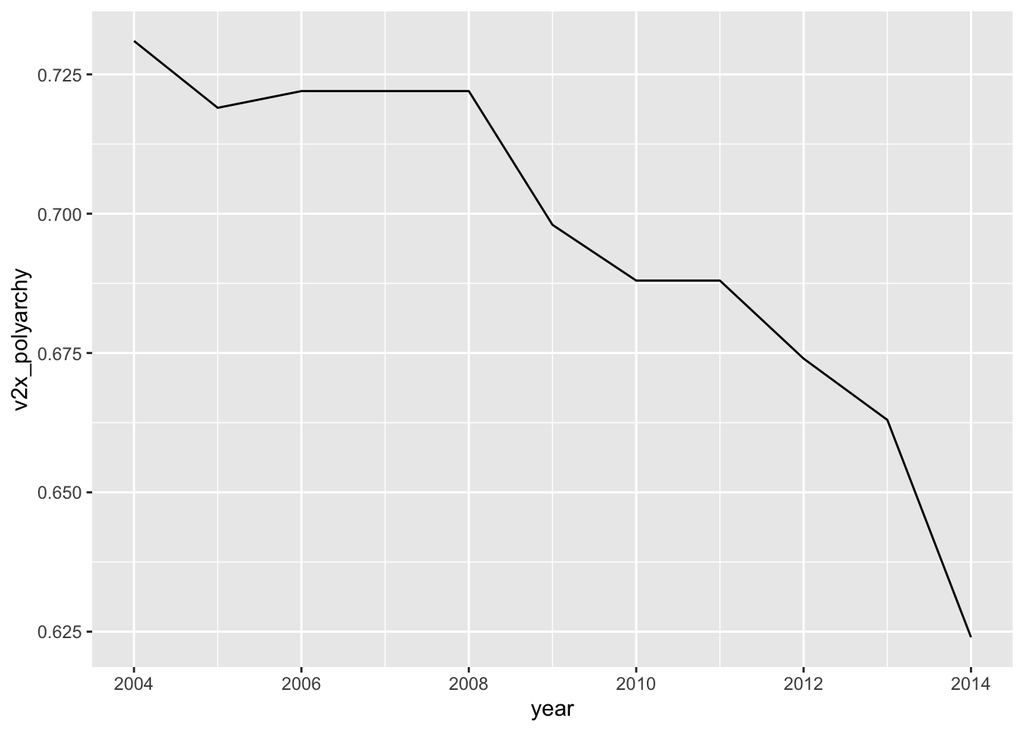

```r
p <- ggplot(df_india, aes(x = year, y = v2x_polyarchy)) +
  geom_line()

p # this will show the plot
```

In this example, we use `<-` to *assign* the plot to a name — in this case, we call it **`p`**.

That means `p` now stores the entire plot we just built using `ggplot()`. You can think of `p` like a saved object — now anytime you type `p`, it will the plot named `p`.

#### 3.2.4.3 Add Points for Readability

- The `+` adds another layer to the existing plot `p`.
- `geom_point()` places dots on each year’s EDI value, helping you see exact data points.
- The same plot `p` now contains both the line and the points.

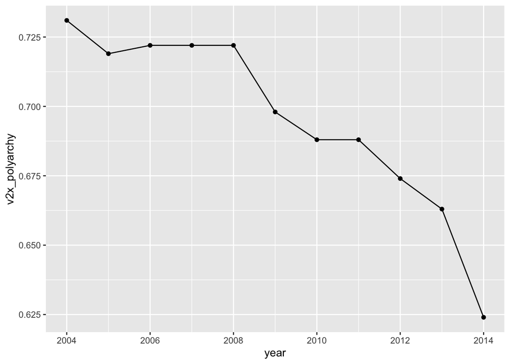

```r
p <- ggplot(df_india, aes(x = year, y = v2x_polyarchy)) +
  geom_line()+
  geom_point()
p
```

#### 3.2.4.4 Add Title, Labels, and a Clean Theme

- `labs()` adds a descriptive title and axis labels.
- The names inside quotation marks will appear on your plot.
- `theme_minimal()` changes the background and grid style to a cleaner look.

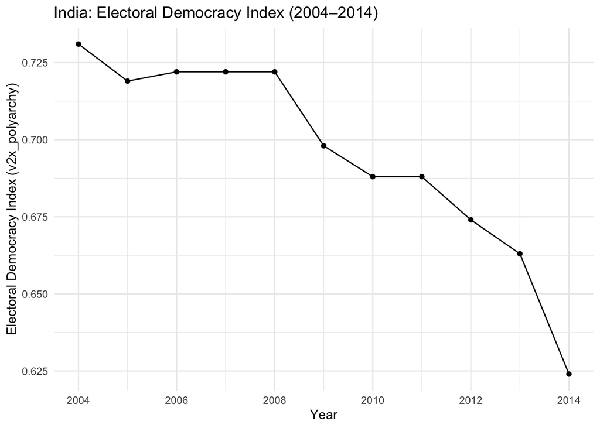

```r
p <- ggplot(df_india, aes(x = year, y = v2x_polyarchy)) +
  geom_line()+
  geom_point()+
  labs(
    title = "India: Electoral Democracy Index (2004–2014)",
    x = "Year",
    y = "Electoral Democracy Index (v2x_polyarchy)"
  ) +
  theme_minimal()
p
```

#### 3.2.4.5 Adjust the Appearance

We can change the overall look of a plot using built-in themes. `ggplot2` offers several options: `theme_minimal()`, `theme_bw()`, `theme_classic()`, etc.

- The theme controls how the background, gridlines, and text look.
- `theme_bw()` gives a clean black-and-white style often used for academic charts.

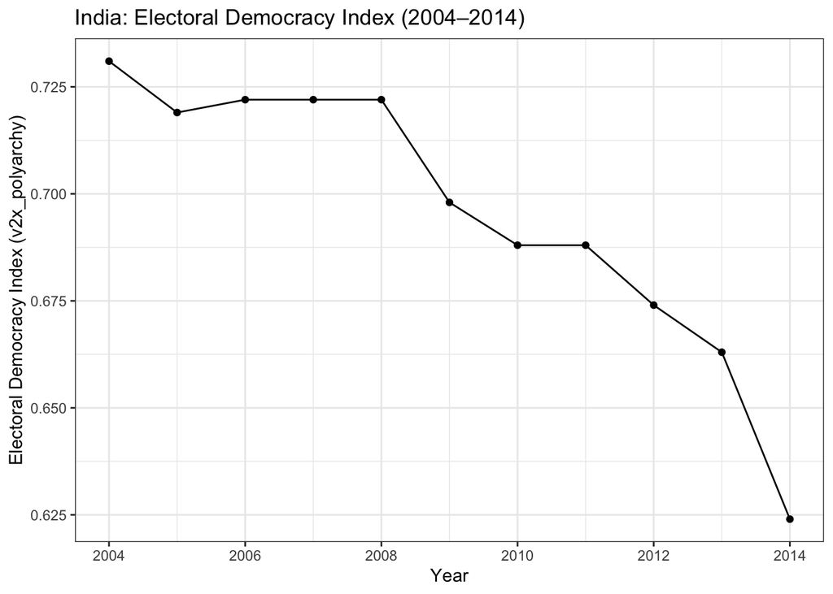

```r
p <- ggplot(df_india, aes(x = year, y = v2x_polyarchy)) +
  geom_line() +
  geom_point() +
  labs(
    title = "India: Electoral Democracy Index (2004–2014)",
    x = "Year",
    y = "Electoral Democracy Index (v2x_polyarchy)"
  ) +
  theme_bw()    # Try changing this to theme_minimal(), theme_light(), or theme_classic()
p
```

- You can experiment with other themes like:
  - `theme_minimal()`: simple and modern
  - `theme_light()`: bright with light grid lines
  - `theme_classic()`: plain background, no grid lines

> 🔍 Besides themes, in `ggplot2`, you can modify almost every elements by addin more arguments or layers. To explore more available themes, check out this guide: [ggplot2 Theme Gallery](https://ggplot2.tidyverse.org/reference/ggtheme.html)

## 3.3 Optional Pratice Plot: change the country

We’ve gone through each step together — now it’s time for you to try it on your own!

Your task:  
Pick **one country** (other than *India* or *Brazil*) and create a customized plot of the Electoral Democracy Index (EDI) from 2004 to 2014.

Your Goals:

- Choose a country
- Make a subset
- Make a plot for your country
  - Try different themes: `theme_light()`, `theme_classic()`, `theme_minimal()`, etc.
  - Edit the *title* and *labels* to match your country
- Save your plot as a *PDF or png* (or screenshot)
- 📤 Submit your plot to Blackboard

### 3.3.1 See what countries are available

Now that you’ve followed the full example, it’s your turn to try it with a **different country**!

Run the code below to see a list of all country names.  
These will print out in the **Console**, so you can choose one we haven’t used yet.

```r
# This line shows all the unique country names in the dataset 'POLI_LIT'
# $country_name tells R to look at just the 'country_name' column
# unique() returns each country name only once (no repeats)

unique(POLI_LIT$country_name)
```

```
##   [1] "Mexico"         "Suriname"       "Sweden"         "Switzerland"
##   [5] "Ghana"          "Japan"          "Russia"         "Albania"
##   [9] "Egypt"          "Yemen"          "Colombia"       "Poland"
##  [13] "Brazil"         "United States"  "Portugal"       "Bangladesh"
##  [17] "Bolivia"        "Haiti"          "Honduras"       "Pakistan"
##  [21] "Senegal"        "Sudan"          "Vietnam"        "Afghanistan"
##  [25] "Argentina"      "Ethiopia"       "India"          "Kenya"
##  [29] "Kosovo"         "Lebanon"        "Nigeria"        "Philippines"
##  [33] "Tanzania"       "Taiwan"         "Thailand"       "Uganda"
##  [37] "Venezuela"      "Benin"          "Bhutan"         "Burkina Faso"
##  [41] "Cambodia"       "Indonesia"      "Mozambique"     "Nepal"
##  [45] "Nicaragua"      "Niger"          "Zambia"         "Zimbabwe"
##  [49] "Guinea"         "Mauritania"     "Canada"         "Australia"
##  [53] "Botswana"       "Burundi"        "Chile"          "Ecuador"
##  [57] "France"         "Germany"        "Guatemala"      "Ireland"
```

[output cut: 19 more lines]

### 3.3.2 Pick a country you want to explore, make a subset

```r
# Here, we change it "Brazil" as example
# And we name the subset "df_brazil"

df_brazil <- POLI_LIT %>%
  filter(country_name == "Brazil" & year >= 2004 & year <= 2014)

df_brazil     # sanity check: expect 11 rows (2004–2014)
```

> 💡 In R, spelling and capitalization matter — the names must **match exactly**. For example, if the dataset uses `"United Kingdom"`, then `"UK"`, `"united kingdom"`, or `"United kingdom"` will not work. To avoid errors, copy the country name *directly from the Console* using `unique()`.

### 3.3.3 Rebuild the plot using the subset

```r
# Replace 'df_brazil' to your subset
# Change the country name in title

p <- ggplot(df_brazil, aes(x = year, y = v2x_polyarchy)) +
  geom_line() +
  geom_point() +
  labs(
    title = "Brazil: Electoral Democracy Index (2004-2014)",
    x = "Year",
    y = "Electoral Democracy Index (v2x_polyarchy)"
  ) +
  theme_minimal()
p
```

> ⚠️ If a country has missing years or `NA` values in its EDI score, the plot may have gaps or fewer points.  
> That’s normal — data coverage varies across countries and years.  
> If you get **0 rows**, double-check spelling and data coverage (the country exists in the data between 2004 and 2014).

### 3.3.4 Save the plot

Now that you’ve created your custom plot, it’s time to save it as a file so you can submit it.

In R, we use the `ggsave()` function to save a plot to your working folder as a **PDF, PNG, or other file format**.

```r
# Save your current plot as a PDF (best for printing or submission)
# Rename the file to match your selected country and last name

ggsave("SELECTEDCOUNTRY_LASTNAME.pdf", plot = p, width = 7, height = 5)

## ggsave("Brazil_Chen.pdf", plot = p, width = 7, height = 5)
```

> 💡 What does `ggsave()` do?  
> It takes the last plot you created (in this case, p) and saves it as a file in your working directory (Posit Cloud project folder). This lets you download it and submit it outside of RStudio — for example, uploading to Blackboard.
- If Download Doesn’t Work
- Take a screenshot of your plot from the Plots pane
- Make sure your title, axes, and years (2004–2014) are visible
- Save the screenshot as a backup for submission

**Alternative: Save Directly from R Studio**

If `ggsave()` feels confusing, you can also export your plot manually using the R Studio interface.

1. After running your plotting code, go to the Plots pane (bottom-right corner).
2. Click the “Export” button right above your plot.
3. Choose “Save as Image…” or “Save as PDF…”
4. In the pop-up window:
   - Rename your file, e.g. `Brazil_Chen.pdf`
   - Choose where to save it (the default is your Posit project folder).
5. Click Save — you’ll see your file appear in the Files pane.

### 3.3.5 Download the saved file from Posit Cloud

1. Look at the Files pane in Posit Cloud (bottom-right corner).
2. Find your saved file — it should appear there.
3. Click the checkbox next to the file name.
4. Click the “More” (⋯) menu or the gear icon, then choose Export → Download to save it to your computer.
5. Rename it with your chosen country, for example: `Taiwan_Chen.pdf`
6. Upload this file in Blackboard → Optional Practice Plot.

[figure not shown]

## 3.4 Knowledge check

### 3.4.1 Pratice Quiz

**1. You must install `ggplot2` every time you open a new R session.**

a) True

b) False

**2. The pipe operator `%>%` helps you write R code that reads step by step.**

a) True

b) False

**3. What happens if you click the broom icon in the Environment pane?**

a) Deletes files from your project

b) Clears all datasets and variables from memory

c) Clears your current plot

# 4 Gen AI for Learning

Before we dive into more hands-on coding, let’s take a moment to talk about **AI tools** and how they can support your learning — especially when it comes time to work on your **final practice plot**.

In this section, we’ll explore how **Generative Artificial Intelligence (GenAI)** can help you:

- Learn new concepts
- Write and debug code
- Tackle tasks more efficiently

We’ll also cover some **best practices** and **important limitations** — because using AI responsibly means understanding both what it can do and what it can’t.

Also, keep in mind: **AI tools evolve rapidly**. As the technology develops, new methods and improvements will continue to appear.However, the core ideas you learn here — about how AI works and what its limitations are — will help you stay informed and make responsible choices as you use these tools in your academic and coding work.

> 💡 Don’t worry — we’ll keep this section simple and jargon-free. The goal is to help you think critically about AI tools and how to use them effectively.

## 4.1 What Is AI, Generative AI, and LLM?

Before we start using AI tools, let’s first understand what we actually mean by *“Artificial Intelligence.”*

The term covers many ideas, from a simple phone assistant to tools like ChatGPT that can write essays or code. Think of this section as building blocks — each concept adds another layer of understanding.

### 4.1.1 Artificial Intelligence (AI)

**Artificial Intelligence (AI)** means using computers to do tasks that normally require human thinking.  
For example:

- When Netflix recommends a movie you might like.
- When your phone unlocks after recognizing your face.
- When Google Maps finds the fastest route to school.

In all these examples, the computer is using data — what it has seen before — to make a smart choice.

AI is the **broadest term** that covers all kinds of “smart” technologies we use daily.

> ✏️ **Simple definition:** AI is when computers are designed to mimic human thinking — by learning from data or experience and then using that to make decisions, predictions, or even generate new content.

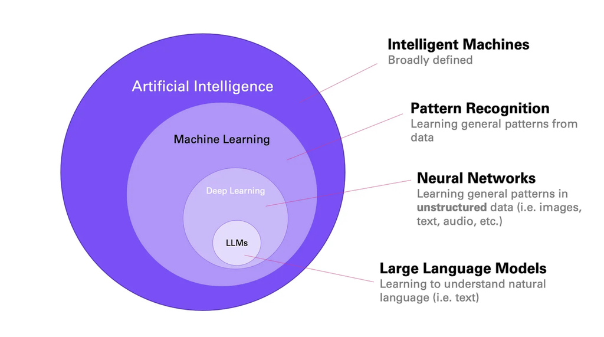

This diagram shows how different types of AI fit inside each other.

**Source:** Stöffelbauer (2023), *How Large Language Models Work.*

### 4.1.2 Machine Learning (ML)

Inside the big world of AI, there is a smaller part called **Machine Learning**. Machine Learning means teaching computers to find patterns and improve with experience — just like how people learn from practice.

Example:

- A spam filter in your email learns which messages are spam after looking at thousands of examples.
- A music app learns what songs you like and recommends similar ones.

> ✏️️ **Simple definition:** Machine Learning helps computers learn automatically from data, without being told every single rule.

### 4.1.3 Deep Learning (DL)

**Deep Learning** is a special kind of machine learning that uses something called *neural networks* — an innovative way of organizing the computer’s learning process (Yep, they are called “neural” because they mimic how neurons in our brain signal one another !).

A *deep learning algorithm* is a type of neural network that has more than three layers — including input, hidden, and output layers. This idea is shown in the diagram below:

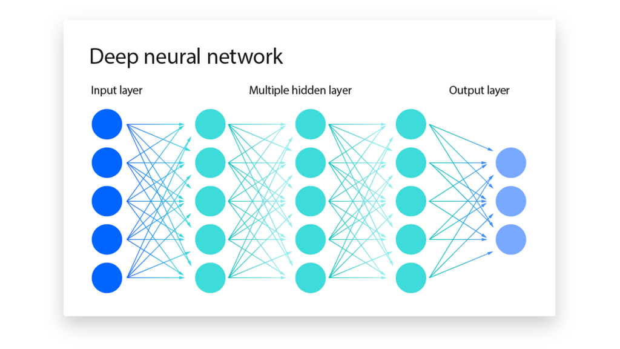

**Source:** IBM Data and AI Team (2024), *AI vs. machine learning vs. deep learning vs. neural networks.*

The “deep” in deep learning refers to the depth of layers in a neural network. This helps it recognize complex patterns like faces, voices, or handwriting.

Example:

- Your phone’s camera can recognize your pet in pictures.
- Speech-to-text programs like Siri or Alexa understand spoken words.

> ✏️ **Simple definition:** Deep Learning is a more advanced type of machine learning that helps computers recognize very complex patterns — like images or voices.

### 4.1.4 Generative AI (GenAI)

Now comes **Generative AI**, the kind that can *create* things.

Instead of just identifying or predicting, this type of AI can generate **new content** — text, images, music, or code — based on what it has learned.

Examples include:

- **ChatGPT:** writes text or code.
- **DALL·E:** creates new images from text prompts.
- **Google Gemini or Copilot:** helps summarize, write, and brainstorm ideas.

> ✏️ **Simple definition:** Generative AI can create new things — like essays, pictures, or programs — by recognizing patterns in huge amounts of data.

**Think of it like this:**  
If you’ve read hundreds of stories, you could probably able to write one that *sounds similar* — even if it’s completely new. That’s what Generative AI does — it learns the style and structure, then creates something new from it.

### 4.1.5 Large Language Models (LLMs)

**Large Language Models** (LLMs) are a type of GenAI focused on text. These models are trained on an enormous amount of text — from books, websites, articles, and code — to learn how people use language.

So take ChatGPT for example, “GPT” stands for Generative Pre-trained Transformer:

- Generative: It creates (generates) new text.
- Pre-trained: It was trained on a massive amount of text before you ever use it.
- Transformer: This is the specific kind of AI model it uses — great at understanding language.

> ✏️ **Simple definition:** LLMs are advanced programs that predict what to say next by recognizing language patterns from huge amounts of text.

LLMs don’t **think** or **understand** like humans. They simply **predict** what word (or sentence) should come next, based on patterns they’ve seen before. LLMs are very good at sounding confident — but the models don’t “understand/know” things.

Sometimes they can make up information that sounds right but isn’t (this is called “hallucination”). That’s why it’s important to **double-check facts** using reliable sources or walk through the **logic** yourself.

### 4.1.6 How These Concepts Fit Together

Here’s a clear table to help you see how everything connects:

| **Concept** | **What It Means** | **Main Function** | **Example in Action** | **Analogy** |
| --- | --- | --- | --- | --- |
| **Artificial Intelligence (AI)** | The overall idea of making computers act smart. | Performs tasks that usually need human thinking. | A self-driving car recognizing stop signs. | The “umbrella” term for all smart systems. |
| **Machine Learning (ML)** | A way for computers to learn from data instead of being programmed by humans. | Learns and improves automatically from examples. | An email filter learning what counts as spam. | Like learning by doing — the more examples, the better it gets. |
| **Deep Learning (DL)** | A type of ML that uses many layers of “neural networks” to recognize complex patterns. | Handles images, sound, and speech with high accuracy. | Siri understanding your voice commands. | Like the brain — many layers process information step by step. |
| **Generative AI (GenAI)** | A type of AI that creates new content such as text, code, or images. | Produces new examples based on what it has learned. | DALL·E generate an image base on prompt. | Like an art student who paints something new after studying many artworks. |
| **Large Language Models (LLMs)** | The system behind tools like ChatGPT that generate and understand text. | Predicts what words or sentences should come next. | ChatGPT or Copilot writing code or essays. | Like an advanced autocomplete tool that has read the internet. |

#### 4.1.6.1 Recommended Resources

If you’d like to explore more about how AI and language models work, here are some short and easy-to-follow resources:

- [**OpenAI’s “How ChatGPT Works” Overview**](https://help.openai.com/en/articles/6783457-what-is-chatgpt)
- [**How Large Language Models Work (Microsoft Data Science Blog)**](https://medium.com/data-science-at-microsoft/how-large-language-models-work-91c362f5b78f)
- [**AI, Machine Learning, Deep Learning and Generative AI Explained (YouTube Video)**](https://youtu.be/qYNweeDHiyU?si=gCa9GosBi2TpsjLY)

## 4.2 Limitations and Ethics of Using GenAI

As you begin using AI tools in your learning and daily work, it is important to think carefully about what AI can and cannot do.

Generative AI is a powerful tool for writing, coding, and problem solving, but it is not a human brain. It does not truly *understand* language or meaning — it simply imitates what understanding looks like by recognizing patterns in data.

> 🔍 **Not a Human Brain**  
> AI systems mimic reasoning but *do not actually think, understand, or know the truth*. They produce text or code by predicting what is likely to come next based on what they have seen in their training data.  
> AI can sound intelligent because its responses are often fluent and well-structured, but this fluency does not mean understanding. Unlike people, AI *does not experience the world, form opinions, or evaluate meaning — it only predicts*.

### 4.2.1 Limitations of AI

Even though Generative AI can produce impressive results, it has clear limits that students must keep in mind:

- **Can generate wrong or made-up information (“hallucinations”).**  
  Sometimes AI invents facts, names, or citations that sound believable but are not real.
- **Lacks real-world context unless you provide it.**  
  It only knows what is written in your prompt; it cannot “guess” what you mean.
- **Can repeat social or data biases.**  
  Because AI learns from human data, it may repeat stereotypes or biased language found in its training material.
- **Does not reason or understand ideas.**  
  It imitates the structure of language, but it cannot truly analyze meaning or intent.

In short, AI is a tool for generating patterns — not a system that understands truth or logic. You should always be the one interpreting, questioning, and verifying what it produces.

### 4.2.2 Ethical Use of AI in Learning

When using AI in academic or professional settings, ethical use means using it to **support your own thinking, not to replace it.**

Here are some basic guidelines for responsible use:

- **Always fact-check AI-generated answers.**  
  Verify statistics, quotes, and claims using trusted academic or official sources.
- **Never submit AI output as your own work.**  
  Passing off AI-generated writing as personal writing is a form of plagiarism.
- **Use AI for learning, not shortcutting.**  
  Ask it to *explain*, *summarize*, or *suggest*, but make sure you still think critically about the result.
- **Remember:** AI does not “know” — it predicts.  
  You are responsible for the accuracy, originality, and integrity of any work that includes AI assistance.

Using AI responsibly means developing judgment — understanding when it helps you think and when it might mislead you.

### 4.2.3 Why Can AI Generate Things So Well (Even Without Thinking)?

You might wonder how AI can produce such fluent text or realistic answers even though it does not think. The reason lies in how these systems are trained.

- AI systems like Large Language Models (LLMs) are trained on **massive amounts of text and data** from books, websites, and code. They learn **probabilities**; given a prompt, they predict which words or phrases are most likely to come next based on patterns in the training data. Because of their size and exposure to so much language, they can **mimic human-like writing or reasoning** very convincingly.
- However, they do **not understand meaning** or reasoning in the way humans do. They have **no goals, beliefs, or consciousness**; they simply select the next most likely token (word or symbol). This is why their answers can appear smart and fluent, yet sometimes are **inaccurate, inconsistent, or shallow** in reasoning.

AI tools can sound like they understand things because they’re very good at predicting what comes next in language or code, but they are not thinking beings. They imitate patterns, rather than reasoning like us.

> *LLMs are like a 12-year-old who has read every classic novel, wiki entry, and Reddit thread — in every language, ever exist — and is trying to sound smart like an adult. But they don’t actually understand what any of it means…. Now imagine that 12-year-old is a robot who doesn’t feel and experience the world like we do…* — Chen (2025), Attempt to teach LLMs in POLI 105

#### 4.2.3.1 Recommended Resources

For more discussion about what AI can and cannot do, and what ethical use means in modern education and research, see:

- [**The Benefits and Limitations of Generative AI: Harvard Experts Answer Your Questions**](https://harvardonline.harvard.edu/blog/benefits-limitations-generative-ai)  
  Explains the advantages and limitations of AI in everyday and professional contexts.
- [**The Limits of AI: Generative AI, NLP, AGI, and What’s Next?**](https://www.microsoft.com/en-us/research/blog/the-limits-of-ai-generative-ai-nlp-agi-and-whats-next/)  
  Discusses what current AI can realistically achieve, and how it differs from human-level intelligence.

## 4.3 “Vibe Coding”

Recently, a new term has been making the rounds in tech and programming circles: **vibe coding.** This idea is exciting and has caught public attention because it seems to promise a future where we can “skip” learning to code and just tell the computer what to do.

> 🔍 Vibe Coding  
> It describes an **AI-assisted coding style** where someone explains what they want in natural (plain) language, and the AI generates most of the code. Instead of typing every line manually, you might guide the AI, test what it creates, and refine the result until it works.

For example, someone might say: “Make a dashboard that shows unemployment trends,” and the AI would generate code automatically. But while this sounds exciting, it is also important to understand what it does—and why **starting with “vibe coding” is not the best way to learn** programming.

We strongly **discourage** jumping straight into vibe coding without first learning the **fundamentals** of how a programming language works — just like most data scientists, researchers, and teachers do.

Gen AI can certainly help you learn a language step by step, but the most effective approach is to use it **as a learning partner**, not as a replacement for learning.

To learn more about the trend, see:

- [Vibe Coding: Collins Dictionary’s Word of the Year 2025 (CNN)](https://www.cnn.com/2025/11/06/tech/vibe-coding-collins-word-year-scli-intl)
- [What Is Vibe Coding (IBM)](https://www.ibm.com/think/topics/vibe-coding)

### 4.3.1 Why You Should Still Learn to Code

Even though AI can write or explain code, learning to code yourself is essential. Understanding the basics of syntax, logic, and data flow gives you control over what the AI generates and helps you think critically about how code works.

- **Understand what AI produces.**  
  Knowing the language helps you evaluate AI-generated code and recognize errors or inefficient solutions.
- **Avoid “copy–paste AI” work.**  
  Without a foundation in coding, you risk relying entirely on AI-generated scripts that you cannot explain or maintain.
- **Build real problem-solving skills.**  
  Coding teaches you structured thinking and debugging—skills that AI can support, but not replace.

#### 4.3.1.1 Why Explore Vibe Coding? And When?

Once you have some coding experience, exploring AI-assisted coding can be valuable.  
It can make your workflow faster and more creative when used properly.

- **Speed and prototyping.**  
  AI can help generate starting points quickly, allowing you to test ideas and adjust your code faster.
- **Accessibility.**  
  Even beginners can create simple projects by describing them in plain language.

> 💡 Learning to code gives you the foundation to use AI effectively and responsibly. Instead of depending on AI, you’ll learn to **collaborate** with it. The key is **balance**: learn the basics first, then use AI tools to expand what you can do more efficiently.

Additional resources:

- [What Is Vibe Coding (IBM)](https://www.ibm.com/think/topics/vibe-coding)
- [Don’t Be a Vibe Coder(Medium)](https://medium.com/data-science-in-your-pocket/dont-be-a-vibe-coder-30fa7c525971)

## 4.4 GenAI-Assisted Coding: Using GenAI as a Learning Tool

Although we do not recommend starting with vibe coding as a beginner, **Generative AI can be a low-cost, customizable, and interactive way to learn programming**. You can use AI to ask questions, fix errors, or clarify coding concepts—especially when you are working in R for this course.

The goal is to use GenAI **to understand code**, not to replace the process of writing it.

### 4.4.1 How GenAI Coding Assistants Work

- GenAI coding tools are powered by **large language models (LLMs)** trained on millions of lines of code and text.
- They can generate, complete, or explain code snippets based on your instructions.
- They do not understand code like humans do; instead, they predict what code “should” follow from your input.

These tools are best used as interactive tutors—helping you learn what the code means and how to fix it.

### 4.4.2 How to Use GenAI Effectively When Learning to Code

Here are some effective strategies for using GenAI in your coding practice:

- **Ask “why,” not just “how.”**  
  Instead of asking “Give me R code to make a plot,” try:  
  *“Explain what each line in this R code does.”*
- **Debug smarter.**  
  If you get an error, copy the message into GenAI and ask:  
  *“What does this error mean in R?”* or *“How can I fix it while keeping my code simple?”*
- **Translate coding concepts.**  
  Ask AI to summarize what a function like `geom_bar()` or `filter()` does—in plain English.
- **Learn by comparison.**  
  Try: *“Can you show me another way to write this R code?”*  
  This helps you see that there are often several valid approaches to a problem.

### 4.4.3 ⚠️ Cautions

- Do not ask GenAI to write an entire script for you. Use it to **explain, clarify, or debug** code you already wrote.
- Always **review and test** AI’s suggestions; even correct-looking code can be wrong or inefficient.
- Use GenAI as a **learning partner**, not a shortcut. Focus on understanding *why* something works — not just repeatedly prompting to “make it work for me.”

### 4.4.4 Prompts Suggestion

You can experiment with GenAI assistants using prompts like these:

| **Goal** | **Example Prompt** |
| --- | --- |
| Understand code | Explain what each line of this `ggplot2` code does and why `geom_point()` is used. |
| Debug | I got the error `unused argument (size = 3)` when using `geom_point()`. What does it mean, and how can I fix it? |
| Clarify options | What’s the difference between `geom_bar()` and `geom_col()` in `ggplot2`? |
| Ask for explanation | How does `theme_minimal()` change the appearance of a plot compared to `theme_bw()`? |

#### 4.4.4.1 Recommended Resources

- [**Tips for Using ChatGPT to Learn R** (R-Bloggers)](https://www.r-bloggers.com/2023/04/tips-for-using-chatgpt-to-learn-r/)
- [**Use ChatGPT to Become an R Programming Wiz** (Code Like a Girl)](https://code.likeagirl.io/use-chatgpt-to-become-an-r-programming-wiz-131db9e2479a)

### 4.4.5 What’s Next: Using GenAI for Support

In the next section, we’ll walk through different types of visualizations you can make in R — and when to use them. Each plot type comes with a **template R code** you can try. Feel free to **modify the code**, test different settings, and use AI tools to help you understand what’s going on.

> 💡 Try asking AI: “What does this line do?” or “How can I change the color or labels in this plot?”

In the final section, you’ll create your own plot using the `POLI_LIT_v1` dataset.

You get to decide **what type of visualization to make** and **what story it tells** — for example:

- Comparing countries or regions
- Exploring changes over time
- Showing relationships between variables

You are encouraged to use an GenAI assistant (such as LLMs like ChatGPT) to help you:

- Understand what each line of code does
- Fix errors or formatting issues
- Try different options or styles

But **do not rely on AI to generate the entire plot for you** — this is your chance to practice and build your own skills.

> 🔍 After finishing, ask yourself:  
> *If I had to make this visualization again without AI, could I do it on my own?*

## Knowledge Check

### Practice Quiz

**1. AI always understands what it says and reasons like a human.**

a) True

b) False

**2. Large Language Models (LLMs) generate text by selecting what word is most likely to come next.**

a) True

b) False

**3. Which of the following is a key limitation of LLMs like ChatGPT?**

a) They hallucinate or make up confident but false answers

b) They only work with spoken language

c) They cannot summarize text

**4. Why should beginners not rely on “vibe coding” alone?**

a) It’s too slow for real projects

b) It requires advanced math

c) It discourages learning core coding logic

# 5 Storytelling with Visuals

Now that you’ve learned how to make your first plot, let’s talk about how to make visuals **tell a story**.

Charts and graphs aren’t just decorations — they’re tools to help us explain what our data means. A strong visualization can turn complex numbers into something meaningful. It can help us understand real-world political questions, such as:

- How democracy changes over time
- Why some countries are wealthier than others
- How elections affect trust in government

In this section, we’ll focus on two key ideas:

1. **What makes a good visualization?**  
   Tips and best practices for creating clear, effective visuals.
2. **Types of common plots**  
   What kinds of plots exist, when to use each one, and how to build them in R.

### 5.0.1 Why Storytelling Matters

When we see a chart, our eyes naturally search for *patterns* — like differences between groups, upward or downward trends, or surprising spikes.

But here’s the thing: your audience might not see what you see. That’s why your job as the creator is to **guide their attention** toward the key message or insight.

Try Asking :

- *What is the most important message I want the viewer to see first?*
- *What question is this plot helping to answer?* or *What information is this plot trying to convey?*

If you make a plot and can answer these questions clearly, you’re already well on your way to telling a compelling story with your data!

## 5.1 Good Visualization

Below is a pie chart made with our `POLI_LIT_v1` dataset. It shows the **number of intergovernmental organizations (IGOs)** in Middle Eastern countries in 2014.

Is this a good visualization? What do you think it’s trying to communicate? Take a moment to examine the chart below.

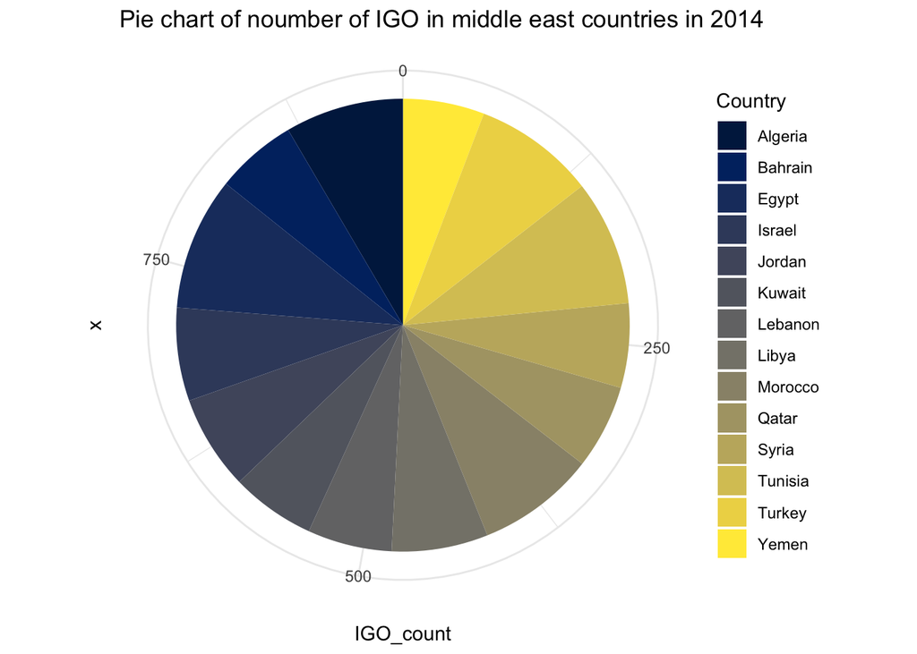

You probably notice, **this is an example of a poor visualization.**  
We’ll go over why it doesn’t work well and how it could be improved soon!

### 5.1.1 Communicate Clearly with Simple, Effective Visuals

A good visualization should make your message **easy to understand — even for someone seeing it for the first time.**  
Your goal isn’t to show off R skills, but to help others quickly grasp what the data means.

Here are some simple but powerful tips:

- **Use clear titles and subtitles**. Tell your reader what to look for.
  - Instead of “GDP vs. Democracy,” try:
  - “Countries with higher GDP per capita tend to have higher democracy scores.”
- **Include context and captions**. Add a short note under your plot that tells the reader:
  - What the data shows (e.g., a trend, comparison, or relationship)
  - The source (e.g., V-Dem v15, World Bank)
  - The time period (e.g., “1990–2022”)
  - Any special notes (e.g., “Small island states excluded due to missing data”)

> 🔍 Example caption:  
> *Source: World Bank (2024). GDP per capita, constant 2015 USD, 1990–2022. Scale begins at zero.*
- **Keep it simple and readable**.
  - Avoid 3-D effects, overly bright colors, or extra gridlines.
  - Use clear fonts and good color contrast (e.g., blue vs. orange).
  - Always label axes and include units (e.g., “GDP per capita (USD, thousands)”).
  - Start numeric axes at zero unless you have a good reason not to — otherwise, small differences might look exaggerated.

> 💡 A great plot is one that people can understand in under a minute — even without extra explanation. Think of yourself as a **storyteller**. Your data is the evidence, and your chart is how you communicate that evidence clearly and credibly to others.

Here’s a simple formula to keep in mind:

> **Question → Data → Chart → Takeaway**

A good chart/plot can be summarize into one clear takeaway sentence, such as:

- Countries with higher democracy scores tend to have greater gender equality.
- From 2000 to 2020, voter turnout declined in nearly every region.
- Despite similar income levels, Country A and Country B have very different levels of press freedom.

## 5.2 When a Chart Doesn’t Work Well

Now let’s revisit the pie chart example and reflect **Why This Is Not a Good Visualization.** Even though this chart runs without any coding errors, it’s not very helpful for understanding the data. Let’s think about why it fails to tell a clear story.

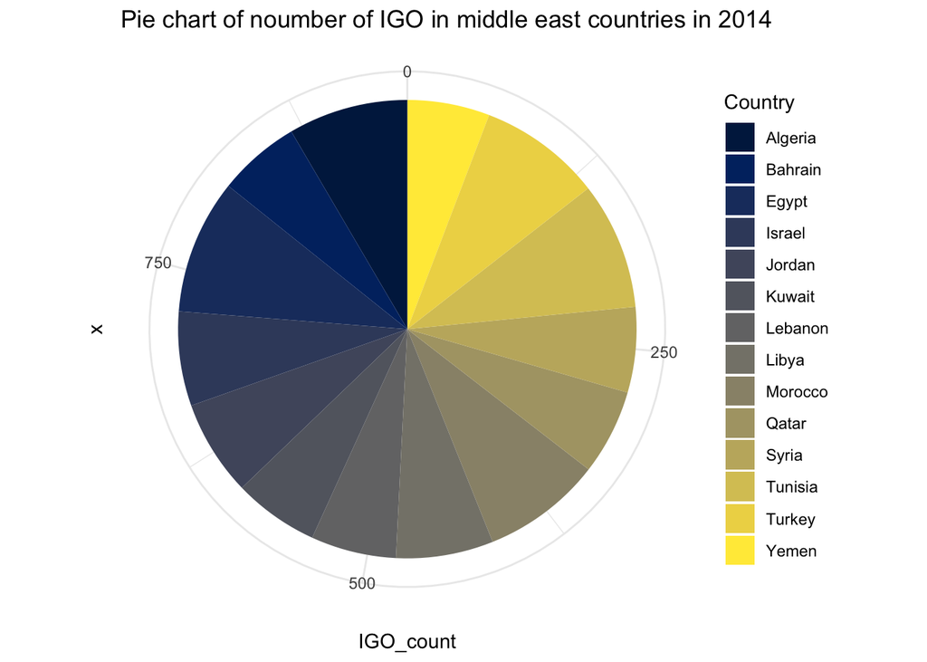

- **The chart doesn’t match the data type.**  
  The variable `IGO_count` represents the *number of intergovernmental organizations* that each country belongs to. Turning that count into a percentage of a circle doesn’t make sense — the values are **not parts of one whole**, but **separate totals** for each country.
- **Too many categories.**  
  A pie chart works best when there are fewer than **five or six categories**. Here, we have many countries, so each slice becomes tiny and hard to read. The viewer can’t easily tell which country has more or fewer IGOs.
- **Color and shape overwhelm rather than help.**  
  The color legend is long and visually overwhelming.
- **No clear takeaway.**  
  What do we actually learn from this chart? It doesn’t show a trend, a comparison, or a relationship — just a collection of similar-looking slices.

### 5.2.1 Lesson from Bad Visualization

Not every type of data fits every kind of plot.  
When choosing a visualization, we should always match it to:

1. The **type of data** — whether it’s categorical, numerical, or time-based, and
2. The **purpose** — what we want to show, compare, or explain.

> 🔍 Reflection:  
> Suppose you want to show the **population percentage** of each country in Europe.

> Would a **scatterplot** be useful here? Probably not. Scatterplots are best when we have two continuous (numeric) variables — for example, *GDP per capita* on the x-axis and *Democracy Score* on the y-axis. Each point represents a pair of values for one observation. These plots are useful for showing *relationships* or *correlations*, not proportions or categories.

> What about a **pie chart**?  
> A pie chart *can* work, but only if you have **a few categories** (e.g., 5–6 countries). If you try to include all the countries in Europe, the pie will be filled with so many tiny slices that it’s impossible to read.

> When you have many categories, it’s usually better to use a **bar chart**, because bars make it easier to compare values side by side.

## 5.3 Exploring Different Types of Visualization

In this section, we’ll explore several common types of visualizations and learn:

- What kind of data each one works best fo
- What research question or purpose it helps answer, and
- How to read and understand the R code that creates it.

### 5.3.1 Pie Chart — Showing Proportions

A **pie chart** shows how different categories make up parts of a whole. Each slice represents a proportion or percentage of total observations.

**What It Is**

- A pie chart divides a circle into slices that represent each category’s share of the total.
- It’s best for showing **simple composition summaries** — not detailed numerical comparisons.

**Type of Data**

- Nominal or categorical variables (e.g., *region*, *IGO participation level*, *income group*).

**Purpose**

- To compare **relative proportions** among a few categories (usually fewer than six).
- To provide a quick overview of how the data is distributed across groups.

#### 5.3.1.1 Example with `ggplot2`: IGO Participation in Sub-Saharan Africa (2014)

Let’s visualize the proportion of IGO participation levels among Sub-Saharan African countries in 2014.

This pie chart shows how many countries fall into each participation level — Low, Medium, or High — based on how many intergovernmental organizations they belonged to.

We’ll use dataset `POLI_LIT_v1` dataset and aggregate the data into categories that work well for visualizing proportions.

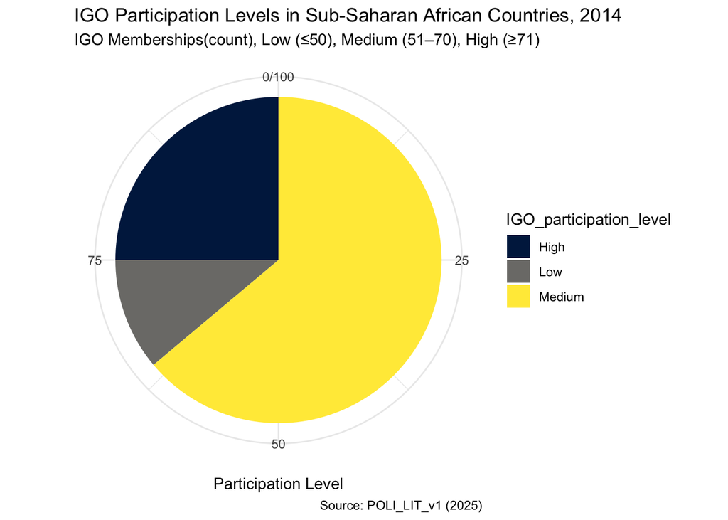

```r
# Pie Chart- IGO Participation in Sub-Saharan Africa (2014)
# Create a subset for the region (e_regionpol_6C == 6) in 2014
data <- POLI_LIT %>%
  filter(e_regionpol_6C == 4, year == 2014)

# Summarize by participation level
summary_latin <- data%>%
  count(IGO_participation_level) %>%
  mutate(prop = n / sum(n) * 100)

# Make a pie chart of proportion by participation level
ggplot(summary_latin, aes(x = "", y = prop, fill = IGO_participation_level)) +
  geom_col(width = 1) +
  coord_polar(theta = "y") +
  labs(
   title = "IGO Participation Levels in Sub-Saharan African Countries, 2014",
    subtitle = "IGO Memberships(count), Low (≤50), Medium (51–70), High (≥71)",
    caption = "Source: POLI_LIT_v1 (2025)",
    y = "Participation Level",
    x = ""
  ) +
  scale_fill_viridis_d(option = "cividis") +
  theme_minimal()
```

```r
# ggplot() starts the plot and defines what data and variables to use.
# aes() maps variables: y determines slice size; fill gives each category a color.
# geom_col() builds proportional bars from the data values.
# coord_polar(theta = "y") converts bars into a circular pie chart.
# labs() adds the title, subtitle, and legend label.
# scale_fill_viridis_d() uses a color-blind-friendly palette.
# theme_minimal() keeps the chart clean and easy to read.
```

#### 5.3.1.2 Why This Chart Works Better than the Previous One

Compared to the earlier “bad example,” this pie chart communicates its message clearly:

- **The variable fits the chart type.**  
  We’re summarizing categories, not numeric totals — a great fit for pie charts.
- **Clear proportions & Simplified categories.**  
  The focus is on how many countries fall into each participation group, not individual values. The use of three broad groups (Low, Medium, High) makes the chart easy to read and interpret.
- **Descriptive caption and title.**  
  Viewers know exactly what they’re looking at, what the levels mean, and what region/timeframe it covers.
- **Clear takeaway.**  
  More than 60% of Sub-Saharan African countries fall into the medium IGO participation level, making it the dominant category. The chart also clearly separates the other levels — this gives a quick, visual summary of how countries in the region are grouped by IGO participation.

#### 5.3.1.3 Visualization is a support tool, not the conclusion

While this chart gives a helpful overview of IGO participation levels, **it doesn’t tell the full story on its own**. A pie chart like this shows proportions — but **not** which specific countries are in each category, what those IGOs are, or why participation levels differ.

To better understand regional participation patterns, pair this chart with information such as:

- A list of Sub-Saharan African countries
- Background on major IGOs active in the region

Together, these elements help turn the chart into a meaningful, evidence-based explanation.

### 5.3.2 What Variables Work Well for Pie Charts?

In our dataset, other variables that fit a pie chart include:

- **`e_regionpol_6C`** — to show what percentage of countries belong to each region.
- **`IGO_participation_level`** — to summarize low, medium, or high levels of IGO engagement.
- **`country_name` grouped by region** — to show how many countries fall into each regional group.

> 💡 Pie charts are best for *simple, few-category comparisons*. If the plots need to include many categories (like 10+ countries), use a **bar chart** instead — it’s easier to read and interpret.

### 5.3.3 Histogram — Visualizing Distributions

A **histogram** shows how continuous values are distributed across intervals (called *bins*). It helps us see the overall *shape* of a variable — for example, whether most countries have high, low, or mid-range scores.

**What It Is**

- A histogram groups numeric values into equal intervals (bins) and counts how many observations fall in each range.
- The height of each bar shows how many cases fall in that interval.

**Type of Data**

- **Continuous** (interval or ratio) variables — e.g., *democracy scores*, *GDP per capita*, *gender equality*.

**Purpose**

- To understand how values **cluster** or **spread** across their range.
- To detect **skewness**, **outliers**, or **bimodal patterns** (two peaks).

#### 5.3.3.1 Example with `ggplot2`: Gender Equality in the Asia-Pacific (2014)

Let’s look at how **gender equality scores** (`v2x_gender`) are distributed among countries in the **Asia and Pacific** region. This index measures how equally men and women enjoy civil liberties, access to power, and participation in society. Scores range from 0 to 1.

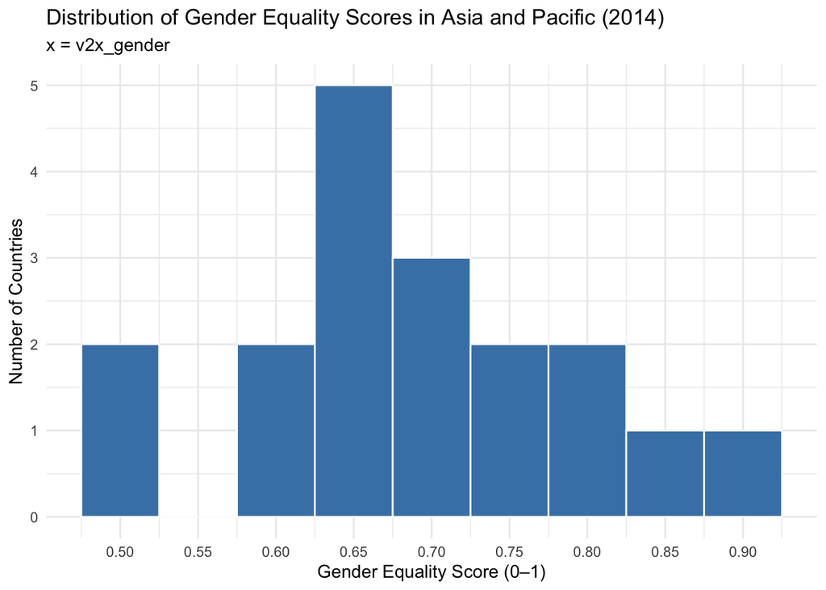

```r
# Subset data for the Asia-Pacific region
data <- POLI_LIT %>%
  filter(e_regionpol_6C == 6, year == 2014)

# Create the histogram
ggplot(data, aes(x = v2x_gender)) +
  geom_histogram(binwidth = 0.05, fill = "steelblue", color = "white") +
   scale_x_continuous(breaks = seq(0, 1, by = 0.05)) +
  labs(
    title = "Distribution of Gender Equality Scores in Asia and Pacific (2014)",
    subtitle = "x = v2x_gender",
    x = "Gender Equality Score (0–1)",
    y = "Number of Countries"
  ) +
  theme_minimal()
```

```r
# ggplot() starts the plot and defines what data/variables to use.
# aes() maps x = v2x_gender, the gender equality score.
# geom_histogram() creates bins (intervals) showing how many countries fall in each range.
# binwidth = 0.05 controls the size of each bin (smaller = more detailed).
# scale_x_continuous() sets consistent tick marks for easier reading.
# fill and color define bar color and outlines.
# labs() adds a title and axis labels.
# theme_minimal() simplifies the layout for readability.
```

#### 5.3.3.2 How to Read This Chart

- **x-axis** → `v2x_gender` (gender equality score, 0 = low equality, 1 = high equality).
- **y-axis** → number of countries falling within each score range.
- **Interpretation:**  
  Countries in the Asia-Pacific region cluster around a moderate level of gender equality — with the tallest bar around the 0.65 range, representing about 5 countries. Only a handful of countries scored above 0.8, as shown by the short bars on the far right.

This histogram gives a quick visual sense of how gender equality varies across the region — and shows that very high scores are rare. This chart helps us see *distribution patterns* in the region.

#### 5.3.3.3 What Other Variables Work Well for Histograms?

Other continuous variables in our dataset include:

A **bar chart** compares numerical summaries — usually averages — across **categories**.  
It’s one of the most common ways to show political or social differences between groups such as regions or years.

**What It Is**

- A bar chart displays the **average value** of a numeric variable for each group.
- It’s ideal for comparing regions, political systems, or other categorical divisions.

**Type of Data**

- **Categorical variable** on the x-axis.
- **Numeric variable** on the y-axis (mean or total).

**Purpose**

- To compare **average values** between categories (e.g., democracy or gender equality by region).
- To show which groups score higher or lower on a specific indicator.

#### 5.3.4.1 Example with `ggplot2`: Average Gender Equality by Region (2014)

Let’s compare the average *Gender Equality Index (v2x_gender)* across world regions in 2014.

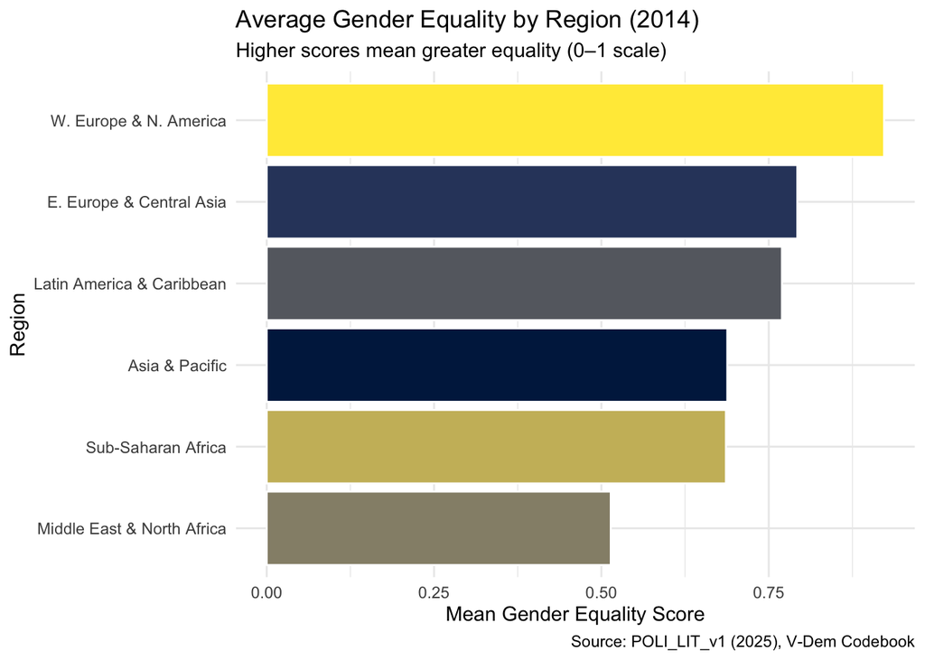

```r
# Create a dataset grouped by region (mean gender equality per region)
data <- POLI_LIT %>%
  filter(year == 2014) %>%
  group_by(e_regionpol_6C) %>%     # group countries by region
  summarise(mean_gender = mean(v2x_gender, na.rm = TRUE)) %>%
  # Add readable region names
  mutate(region_name = case_when(
    e_regionpol_6C == 1 ~ "E. Europe & Central Asia",
    e_regionpol_6C == 2 ~ "Latin America & Caribbean",
    e_regionpol_6C == 3 ~ "Middle East & North Africa",
    e_regionpol_6C == 4 ~ "Sub-Saharan Africa",
    e_regionpol_6C == 5 ~ "W. Europe & N. America",
    e_regionpol_6C == 6 ~ "Asia & Pacific"
  ))

# Create the bar chart
ggplot(data, aes(x = reorder(region_name, mean_gender), y = mean_gender, fill = region_name)) +
  geom_bar(stat = "identity", color = "white") +
  labs(
    title = "Average Gender Equality by Region (2014)",
    subtitle = "Higher scores mean greater equality (0–1 scale)",
    x = "Region",
    y = "Mean Gender Equality Score",
    fill = "Region",
    caption = "Source: POLI_LIT_v1 (2025), V-Dem Codebook"
  ) +
  coord_flip() +  # horizontal bars for readability
  scale_fill_viridis_d(option = "cividis", guide = "none") +
  theme_minimal()
```

```r
# aes() maps variables: x = region name (ordered by value), y = average gender score, fill = region color.
# geom_bar(stat = "identity") creates bars based on actual values (not counts).
# color = "white" adds a clean outline to each bar.
# labs() adds the title, subtitle, axis labels, legend title, and a data source caption.
# coord_flip() rotates the bar chart to horizontal for better readability.
# scale_fill_viridis_d() uses a color-blind-friendly palette.
# guide = "none" hides the redundant legend since region names are already on the axis.
# theme_minimal() applies a clean and simple visual style to the chart.
```

#### 5.3.4.2 How to Read This Chart

- **x-axis** → `e_regionpol_6C` (region codes).
- **y-axis** → `mean_gender`: average Gender Equality Index in 2014
- **Interpretation:**  
  Regions like Western Europe & North America show the highest average scores — indicating more equal access and representation across genders. This bar chart helps you quickly compare levels of gender equality across global regions in a single year.

#### 5.3.4.3 What Variables Work Well for Bar Charts?

Other useful combinations include:

- **`e_regionpol_6C` + `v2x_polyarchy`** — average democracy levels by region.
- **`year` + `e_gdppc`** — shows how average GDP changes over time.

#### 5.3.4.4 Histogram vs. Bar Chart — What’s the Difference?

Although they may look similar, **histograms** and **bar charts** display different types of data:

- **Histogram → continuous (numeric) data** Groups numbers into *intervals (bins)* to show distributions.  
  Example: GDP per capita — how many countries fall within each income range.  
  Bars *touch* because data are continuous.
- **Bar Chart → categorical data** Compares *averages or totals* across categories.  
  Example: average gender equality by region.  
  Bars are *separated by space* because categories are distinct.

> 🔍 **In short:**  
> A histogram shows the *shape of a distribution*,  
> while a bar chart compares *values across groups*.

### 5.3.5 Line Plot — Change Over Time

A **line plot** connects points across time to show **how values change**.  
It helps us see long-term **trends**, such as growth, decline, or stability in political, economic, or social indicators.

**What It Is**

- A line plot displays data points connected by lines.
- Each point represents a year (x-axis) and the value of a variable (y-axis).

**Type of Data**

- Time-series data — a numeric variable that changes across years.

**Purpose**

- To show **changes or trends** over time.
- Useful for tracking patterns such as increases, declines, or fluctuations.
- Common for political, economic, and social indicators (e.g., democracy, GDP, IGO participation).

### 5.3.6 Example: IGO Membership of Japan Over Time

Let’s visualize how Japan’s **number of IGO memberships (`IGO_count`)** has changed over ten years.

[figure not shown]

```r
# Subset data for Japan
data <- POLI_LIT %>%
  filter(country_name == "Japan", year >= 2004, year <= 2014)

# Create the line plot
ggplot(data, aes(x = year, y = IGO_count)) +
  geom_line(color = "#3B82F6", size = 1) +
  geom_point(color = "#1E40AF", size = 2) +
  labs(
    title = "Japan’s IGO Membership Over Time (2005–2014)",
    subtitle = "x = year, y = IGO_count",
    x = "Year",
    y = "Number of IGO Memberships"
  ) +
  theme_minimal()
```

```r
# ggplot() starts the plot and defines which variables to use.
# aes() maps x = year and y = IGO_count.
# geom_line() draws a continuous line connecting yearly data points.
# geom_point() adds circles at each year for visibility.
# labs() adds the title, subtitle, and axis labels.
# theme_minimal() keeps the design clean.
```

### 5.3.7 How to Read This Chart

- **x-axis** → years (2004–2014).
- **y-axis** → number of IGO memberships (`IGO_count`).
- **Interpretation:**  
  Each point shows how many IGOs Japan belonged to that year.  
  If the line rises, Japan is joining more IGOs over time; if it falls, memberships are decreasing. The shape of the line helps identify *trends* — steady growth, fluctuations, or flat patterns.

### 5.3.8 What Variables Work Well for Line Plots?

Other good examples in our dataset include:

- **`v2x_polyarchy`** — democracy index over time for a selected country.
- **`e_gdppc`** — GDP per capita change across years.
- **`v2x_gender`** — gender equality index by year, showing progress or stagnation.

> 💡 Line plots are best for variables that evolve over time — use them to tell a “story of change.”

### 5.3.9 Scatter Plot — Exploring Relationships

A **scatter plot** shows how two numeric variables relate to each other.  
Each dot represents one observation (for example, one country), placed according to two values: one on the x-axis and one on the y-axis.

**What It Is**

A scatter plot positions points on a grid — one variable on the x-axis, one on the y-axis — to show patterns, clusters, or relationships between them.

**Type of Data**

- **Two continuous (numeric) variables**, such as democracy, GDP, or equality measures.

**Purpose**

- To examine whether two variables move together.
- To identify **correlations** — positive, negative, or none.
- To spot **outliers** or unusual cases that don’t follow the general trend.